# Un Juego Simple

# El juego de San Petersburgo (Parte 1)

- Un jugador lanza una moneda. Si obtiene cara, entonces ganará dos puntos. Si obtiene sello deberá volver a lanzar.
- Si en el segundo lanzamiento obtiene cara, ganará 4 puntos. Si obtiene sello deberá volver a lanzar.
- En general, el jugador deberá lanzar la moneda tantas veces como sea necesario para obtener una cara.
- Si la cara se obtiene en el $𝑛 − é𝑠𝑖𝑚𝑜$ lanzamiento, el jugador ganará 2! puntos.
- Simule el juego descrito anteriormente y encuentre el promedio de puntos obtenidos por él jugador, suponiendo que el juego se repite n-veces.
- Visualice una serie de tiempo donde se vea el cambio de los puntos promedio obtenidos por el jugador para valores de 𝑛 de 10, 100, 1000 y 10.000
- Calcule los puntos promedio obtenidos por el jugador en 1000 juegos diferentes (cada juego con 1000 repeticiones) y genere un histograma con el número de puntos obtenidos por el jugador.
- Interprete los resultados en comparación con los obtenidos en el punto anterior.

```python
# Función para simular un solo juego, ahora con probabilidad variable para obtener cara
def simular_juego(prob_cara):
    lanzamientos = 0
    while True:
        lanzamientos += 1
        if np.random.rand() < prob_cara:  # Probabilidad variable de obtener cara
            return 2 ** lanzamientos  # Gana 2^lanzamientos puntos cuando sale cara
```

```python
# Función para simular n juegos y devolver los puntos promedio
def simular_juegos(n, prob_cara):
    puntos = [simular_juego(prob_cara) for _ in range(n)]
    return puntos
```

```python
# Función para visualizar el promedio de puntos obtenidos
def visualizar_promedio(n_valores, prob_cara, prob_name):
    promedios = []
    for n in n_valores:
        puntos = simular_juegos(n, prob_cara)
        promedio = np.cumsum(puntos) / np.arange(1, n+1)
        promedios.append(promedio[-1])
        plt.plot(np.arange(1, n+1), promedio, label=f'{prob_name}, n = {n}')

    plt.xlabel('Número de juegos')
    plt.ylabel('Promedio de puntos')
    plt.title(f'Promedio de puntos por número de juegos (Prob. cara = {prob_name})')
    plt.legend()
    plt.show()
```

```python
# Función para generar histograma con 1000 juegos de 1000 repeticiones
def generar_histograma(n_juegos=1000, n_repeticiones=1000, prob_cara=0.5, prob_name="50%"):
    promedios_finales = [np.mean(simular_juegos(n_repeticiones, prob_cara)) for _ in range(n_juegos)]
    plt.hist(promedios_finales, bins=20, edgecolor='black')
    plt.xlabel('Puntos promedio obtenidos')
    plt.ylabel('Frecuencia')
    plt.title(f'Histograma de puntos promedio en {n_juegos} juegos con {n_repeticiones} repeticiones\n(Prob. cara = {prob_name})')
    plt.show()
```

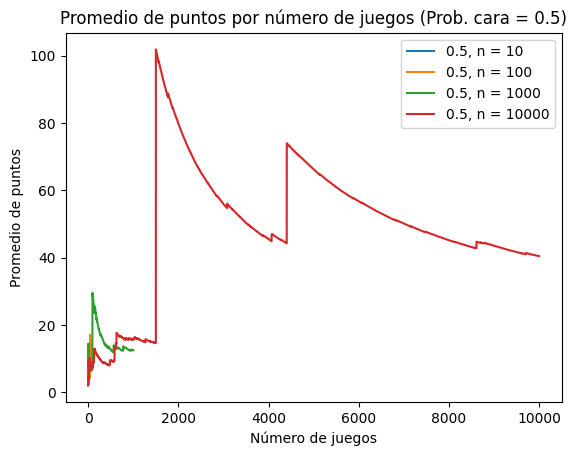

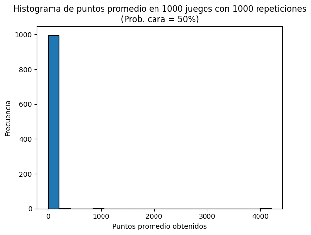

```python
# Simulamos los puntos promedio obtenidos para diferentes valores de n
n_valores = [10, 100, 1000, 10000]
visualizar_promedio(n_valores, 0.5, 0.5)

# Generamos el histograma de puntos promedio obtenidos
generar_histograma()
```